# Working with Categorical Data 1

Billie Anderson, Mark Newman

2020-08-17

## Agenda

- Working with data in R
- Next Homework

# Working with R data: vectors, matrices, arrays and data frames

R works with data in many formats. Most important for us to understand for this course are

- vectors
- matrices
- arrays
- data frames

# Vectors

A *vector* is a collection of values like numbers, character strings or logicals (`TRUE`, `FALSE`), and often correspond to a variable in an analysis.

# Matrices

*Matrices* are rectangular arrays like a traditional table, composed of vectors in their columns and rows.

# Arrays

*Arrays* add additional dimensions, so that, for example, a 3-way table can be represented as composed of rows, columns, and layers.

An important consideration is that the values in vectors, matrices, and arrays must all be of the same *mode*, e.g., numbers or character strings.

# Data Frame

A *data frame* is a rectangular table, like a traditional data set in other statistical environments, and composed of rows and columns like a matrix, but allowing variables (columns) of different types.

# Visual of Different Data Format Types in R

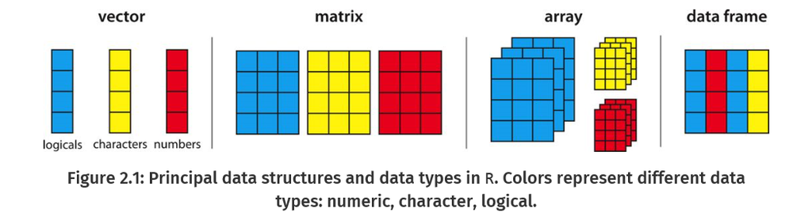

# Vectors

```r
c(17, 20, 15, 40)
```

```
## [1] 17 20 15 40
```

```r
c("female", "male", "female", "male")
```

```
## [1] "female" "male"   "female" "male"
```

# Vectors (cont.)

To store these values in variables, R uses the assignment operator (`<-`) or equals sign (`=`).

This creates a variable named on the left-hand side. An assignment doesn’t print the result, but a bare expression does, so you can assign and print by surrounding the assignment with `()`.

```r
count <- c(17, 20, 15, 40)  #assign
count                       #print
```

```
## [1] 17 20 15 40
```

```r
sex <- c("female", "male", "female", "male")   #assign
sex                                            #print
```

```
## [1] "female" "male"   "female" "male"
```

# Useful Functions for Creating Vectors

The `:` operator for generating consecutive integer sequences, e.g., 1:10 gives the integers 1 to 10.

```r
1:10
```

```
##  [1]  1  2  3  4  5  6  7  8  9 10
```

# Useful Functions for Creating Vectors (cont.)

The `seq()` function is more general, taking the forms `seq(from, to)`, `seq(from, to, by=)`, and `seq(from, to, length.out=)` where the optional argument by specifies the interval between adjacent values and `length.out` gives the desired length of the result.

```r
seq(10, 100, by=10)
```

```
##  [1]  10  20  30  40  50  60  70  80  90 100
```

```r
seq(0, 1, length.out = 11)
```

```
##  [1] 0.0 0.1 0.2 0.3 0.4 0.5 0.6 0.7 0.8 0.9 1.0
```

# Useful Functions for Creating Vectors (cont.)

The `rep()` function generates repeated sequences, replicating its first argument (which may be a vector) a given number of times, and individual elements can be repeated with each until an optional `length.out` is obtained.

```r
rep("male", times=2)
```

```
## [1] "male" "male"
```

```r
rep(c("female", "male"), times=2)
```

```
## [1] "female" "male"   "female" "male"
```

```r
rep(c("female", "male"), length.out=4)
```

```
## [1] "female" "male"   "female" "male"
```

# Matrices

A *matrix* is a two-dimensional array of elements of the same type composed in a rectangular array of rows and columns.

Matrices can be created by the function matrix(values, nrow, ncol), which reshapes the elements in the first argument (values) to a matrix with nrow rows and ncol columns. By default, the elements are filled in columnwise, unless the optional argument byrow = TRUE is given.

The last example illustrates that the values in the first argument are recycled as necessary to fill the given number of rows and columns.

```r
matA <- matrix(1:8, nrow = 2, ncol = 4)
matA
```

```
##      [,1] [,2] [,3] [,4]
## [1,]    1    3    5    7
## [2,]    2    4    6    8
```

```r
matB <- matrix(1:8, nrow = 2, ncol = 4, byrow = T)
matB
```

```
##      [,1] [,2] [,3] [,4]
## [1,]    1    2    3    4
## [2,]    5    6    7    8
```

```r
matC <- matrix(1:4, nrow = 2, ncol = 4)
matC
```

```
##      [,1] [,2] [,3] [,4]
## [1,]    1    3    1    3
## [2,]    2    4    2    4
```

# Matrices (cont.)

All matrices have a dimensions attribute, a vector of length two giving the number of rows and columns, retrieved with the function `dim()`.

Labels for the rows and columns can be assigned using `dimnames()`, which takes a list of two vectors for the row names and column names, respectively.

To see the structure of a matrix (or any other R object) and its attributes, you can use the `str()` function.

```r
dim(matA)
```

```
## [1] 2 4
```

```r
str(matA)
```

```
##  int [1:2, 1:4] 1 2 3 4 5 6 7 8
```

```r
dimnames(matA) <- list(c("M", "F"), LETTERS[1:4])
matA
```

```
##   A B C D
## M 1 3 5 7
## F 2 4 6 8
```

```r
str(matA)
```

```
##  int [1:2, 1:4] 1 2 3 4 5 6 7 8
##  - attr(*, "dimnames")=List of 2
##   ..$ : chr [1:2] "M" "F"
##   ..$ : chr [1:4] "A" "B" "C" "D"
```

# Matrices (cont.)

Additionally, names for the row and column *variables* themselves can also be assigned in the dimnames call by giving each dimension vector a name.

`LETTERS` is a predefined character vector of the 26 uppercase letters.

```r
dimnames(matA) <- list(sex=c("M", "F"), group = LETTERS[1:4])

matA
```

```
##    group
## sex A B C D
##   M 1 3 5 7
##   F 2 4 6 8
```

```r
str(matA)
```

```
##  int [1:2, 1:4] 1 2 3 4 5 6 7 8
##  - attr(*, "dimnames")=List of 2
##   ..$ sex  : chr [1:2] "M" "F"
##   ..$ group: chr [1:4] "A" "B" "C" "D"
```

# Matrices (cont.)

Matrices can also be created or enlarged by “binding” vectors or matrices together by rows or columns:

- `rbind(a, b, c)` creates a matrix with the vectors a, b, and c as its rows, recycling the elements as necessary to the length of the longest one.
- `cbind(a, b, c)` creates a matrix with the vectors a, b, and c as its columns.
- `rbind(mat, a, b, .)` and `cbind(mat, a, b, .)` add additional rows (columns) to a matrix mat, recycling or subsetting the elements in the vectors to conform with the size of the matrix.

```r
rbind(matA, c(10, 20))
```

```
##    A  B  C  D
## M  1  3  5  7
## F  2  4  6  8
##   10 20 10 20
```

```r
cbind(matA, c(10, 20))
```

```
##   A B C D
## M 1 3 5 7 10
## F 2 4 6 8 20
```

# Matrices (cont.)

Rows and columns can be swapped (transposed) using `t()`

```r
t(matA)
```

```
##      sex
## group M F
##     A 1 2
##     B 3 4
##     C 5 6
##     D 7 8
```

Basic computations involving matrices are performed *element-wise*:

```r
2 * matA / 100
```

```
##    group
## sex    A    B    C    D
##   M 0.02 0.06 0.10 0.14
##   F 0.04 0.08 0.12 0.16
```

When you need to multiply matrices, you can use the `%*%` special operator.

# Arrays

Higher-dimensional arrays are less frequently encountered in traditional data analysis, but they are of great use for categorical data, where frequency tables of three or more variables can be naturally represented as arrays, with one dimension for each table variable

The function `array(values, dim)` takes the elements in values and reshapes these into an array whose dimensions are given in the vector dim.

The number of dimensions is the length of dim.

As with matrices, the elements are filled in with the first dimension (rows) varying most rapidly, then by the second dimension (columns) and so on for all further dimensions, which can be considered as layers.

A matrix is just the special case of an array with two dimensions.

# Arrays (cont.)

Let’s look at an example.

```r
dims <- c(2, 4, 2)

arrayA <- array(1:16, dim=dims)  #2 rows, 4 columns, 2 layers
arrayA
```

```
## , , 1
##
##      [,1] [,2] [,3] [,4]
## [1,]    1    3    5    7
## [2,]    2    4    6    8
##
## , , 2
##
##      [,1] [,2] [,3] [,4]
## [1,]    9   11   13   15
## [2,]   10   12   14   16
```

```r
str(arrayA)
```

```
##  int [1:2, 1:4, 1:2] 1 2 3 4 5 6 7 8 9 10 ...
```

```r
arrayB <- array(1:16, dim = c(2, 8))   #2 rows 8 columns
arrayB
```

```
##      [,1] [,2] [,3] [,4] [,5] [,6] [,7] [,8]
## [1,]    1    3    5    7    9   11   13   15
## [2,]    2    4    6    8   10   12   14   16
```

```r
str(arrayB)
```

```
##  int [1:2, 1:8] 1 2 3 4 5 6 7 8 9 10 ...
```

# Arrays (cont.)

In the same way that we can assign labels to the rows and columns in matrices, we can assign these attributes to `dimnames(arrayA)`, or include this information in a `dimnames()` argument to array ().

```r
dimnames(arrayA) <- list(sex = c("M", "F"), group = letters[1:4],
                         time = c("Pre", "Post"))
arrayA
```

```
## , , time = Pre
##
##    group
## sex a b c d
##   M 1 3 5 7
##   F 2 4 6 8
##
## , , time = Post
##
##    group
## sex  a  b  c  d
##   M  9 11 13 15
##   F 10 12 14 16
```

Arrays in R can contain any single type of elements-numbers, character strings, logicals. R also has a variety of functions like `table()` and `xtabs()` for creating and manipulating a “table” objects, which are specialized forms of matrices and arrays containing integer frequencies in a contingency table.

# Data Frames

Data frames are the most commonly used form of data in R and more general than matrices in that they can contain columns of different types.

For statistical modeling, data frames play a special role, in that many modeling functions are designed to take a data frame as a data= argument, and then find the variables mentioned within that data frame.

Another distinguishing feature is that discrete variables (columns) like character strings (“M”, “F”) or integers (1, 2, 3) in data frames can be represented as *factors*, which simplifies many statistical and graphical methods.

The function `data.frame()` creates and manipulates data frames. The function `data.frame()`can be applied to a list of objects, `data.frame(a, b, c)`, each of which can be a vector, matrix, or another data frame, but typically all containing the same number of rows.

# Data Frames (cont.)

Let’s look at an example.

```r
set.seed(12345)  #reproducibility

n <- 100
A <- factor(sample(c("a1", "a2"), n, replace = TRUE))
B <- factor(sample(c("a1", "a2"), n, replace = TRUE))
sex <- factor(sample(c("M", "F"), n, replace = TRUE))
age <- round(rnorm(n, mean=30, sd=5))
mydata <- data.frame(A, B, sex, age)

head(mydata, 5)
```

```
##    A  B sex age
## 1 a2 a1   F  22
## 2 a1 a1   M  33
## 3 a2 a1   F  31
## 4 a2 a2   M  26
## 5 a2 a1   M  29
```

```r
str(mydata)
```

```
## 'data.frame':    100 obs. of  4 variables:
##  $ A  : Factor w/ 2 levels "a1","a2": 2 1 2 2 2 2 2 1 1 2 ...
##  $ B  : Factor w/ 2 levels "a1","a2": 1 1 1 2 1 1 1 1 2 1 ...
##  $ sex: Factor w/ 2 levels "F","M": 1 2 1 2 2 2 2 1 2 2 ...
##  $ age: num  22 33 31 26 29 29 38 28 30 27 ...
```

# Data Frames (cont.)

Rows, columns, and individual values in a data frame can be manipulated in the same way as a matrix, using subscripting (`[,]`). And, variables can be extracted using the `$` operator.

```r
mydata[1,2]
```

```
## [1] a1
## Levels: a1 a2
```

```r
mydata$sex #same as mydata[,3] or mydata[,"sex"]
```

```
##   [1] F M F M M M M F M M M M M M M M M F F M M M F F F M F M M M F M F F F F F
##  [38] M M M F F F M F M M M F F M F F M F M M F F F F F M F M M M M M F M M M M
##  [75] F M F F F M M F M F F F F F M M F M M M F F F F M F
## Levels: F M
```

# Data Frames (cont.)

You may have external data sets you want to import into R, like csv files.

The function `read.table()` has many options to control the details of how the data are read and converted to variables in the data frame. Among these some important options are:

- header indicates whether the first line contains variable names. The default is `FALSE` unless the first line contains one fewer field than the number of columns
- `sep` (default: "", meaning white space, i.e., one or more spaces, tabs or newlines) specifies the separator character between fields
- `stringsAsFactors` (default: `TRUE`) determines whether character string variables should be converted to factors
- `na.strings` (default: “NA”) refers to one or more strings that are interpreted as missing data values (NA)

# Example: Importing the Arthritis Data

We have a .csv file that contains information about the 84 arthritis patients. Going to bring this file into R and convert it to a data frame.

```r
path <- "ch02/Arthritis.csv" #setting path

Arthritis <- read.table(path, header=TRUE, sep=",")

str(Arthritis)
```

```
## 'data.frame':    84 obs. of  5 variables:
##  $ ID       : int  57 46 77 17 36 23 75 39 33 55 ...
##  $ Treatment: Factor w/ 2 levels "Placebo","Treated": 2 2 2 2 2 2 2 2 2 2 ...
##  $ Sex      : Factor w/ 2 levels "Female","Male": 2 2 2 2 2 2 2 2 2 2 ...
##  $ Age      : int  27 29 30 32 46 58 59 59 63 63 ...
##  $ Improved : Factor w/ 3 levels "Marked","None",..: 3 2 2 1 1 1 2 1 2 2 ...
```

```r
head(Arthritis)
```

```
##   ID Treatment  Sex Age Improved
## 1 57   Treated Male  27     Some
## 2 46   Treated Male  29     None
## 3 77   Treated Male  30     None
## 4 17   Treated Male  32   Marked
## 5 36   Treated Male  46   Marked
## 6 23   Treated Male  58   Marked
```

# Example (cont.)

Notice the ordering of the Treatment and Improved Variables. Since Improved is an ordinal variable, we want the levels to be in the appropriate order, None, Some, Marked. We can rearrange these levels using the `ordered()` function.

```r
levels(Arthritis$Improved)
```

```
## [1] "Marked" "None"   "Some"
```

```r
Arthritis$Improved <- ordered(Arthritis$Improved, levels=c("None", "Some", "Marked"))

str(Arthritis)
```

```
## 'data.frame':    84 obs. of  5 variables:
##  $ ID       : int  57 46 77 17 36 23 75 39 33 55 ...
##  $ Treatment: Factor w/ 2 levels "Placebo","Treated": 2 2 2 2 2 2 2 2 2 2 ...
##  $ Sex      : Factor w/ 2 levels "Female","Male": 2 2 2 2 2 2 2 2 2 2 ...
##  $ Age      : int  27 29 30 32 46 58 59 59 63 63 ...
##  $ Improved : Ord.factor w/ 3 levels "None"<"Some"<..: 2 1 1 3 3 3 1 3 1 1 ...
```

# Forms of Categorical Data: case form, frequency form and table form

We will be working with these three forms of data throughout the class.

# Case Form

Categorical data in case form are simply data frames, with one or more discrete classifying variables or response variables, most conveniently represented as factors or ordered factors.

The Arthritis data that we imported into R in Chapter 2 Section 1 is in case form.

```r
path <- "ch02/Arthritis.csv" #setting path

Arthritis <- read.table(path, header = TRUE, sep=",")

Arthritis$Improved <- ordered(Arthritis$Improved, levels=c("None", "Some", "Marked"))

str(Arthritis) #shows the structure
```

```
## 'data.frame':    84 obs. of  5 variables:
##  $ ID       : int  57 46 77 17 36 23 75 39 33 55 ...
##  $ Treatment: Factor w/ 2 levels "Placebo","Treated": 2 2 2 2 2 2 2 2 2 2 ...
##  $ Sex      : Factor w/ 2 levels "Female","Male": 2 2 2 2 2 2 2 2 2 2 ...
##  $ Age      : int  27 29 30 32 46 58 59 59 63 63 ...
##  $ Improved : Ord.factor w/ 3 levels "None"<"Some"<..: 2 1 1 3 3 3 1 3 1 1 ...
```

```r
head(Arthritis,5)  #first 5 rows of Arthritis
```

```
##   ID Treatment  Sex Age Improved
## 1 57   Treated Male  27     Some
## 2 46   Treated Male  29     None
## 3 77   Treated Male  30     None
## 4 17   Treated Male  32   Marked
## 5 36   Treated Male  46   Marked
```

# Frequency Form

Data in frequency form can also be represented as a data frame. Usually there is a variable ‘Freq’ or ‘Count’ that is the count of the number of observations in that category (or cell if we think of the contingency table format).

# Example: General Social Survey

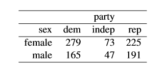

Let’s use R and re-create this data in frequncy form as a data frame.

```r
GSS <- data.frame(
  expand.grid(sex=c("female", "male"),
              party=c("dem", "indep", "rep")),
  count=c(279,165,73,47,225,191))

str(GSS)
```

```
## 'data.frame':    6 obs. of  3 variables:
##  $ sex  : Factor w/ 2 levels "female","male": 1 2 1 2 1 2
##  $ party: Factor w/ 3 levels "dem","indep",..: 1 1 2 2 3 3
##  $ count: num  279 165 73 47 225 191
```

```r
head(GSS)
```

```
##      sex party count
## 1 female   dem   279
## 2   male   dem   165
## 3 female indep    73
## 4   male indep    47
## 5 female   rep   225
## 6   male   rep   191
```

```r
sum(GSS$count)
```

```
## [1] 980
```

# Table Form

Table form data is represented as a matrix, array, or table object whose elements are the frequencies in an n-way table.

The number of dimensions of the table is the length, `length(dim(X))`, of its dim (or dimnames) attribute, and the sizes of the dimensions in the table are the elements of `dim(X)`.

The total number of observations represented is the sum of all the frequencies, `sum(X)`.

# Example: Hair and Eye Color

```r
data("HairEyeColor",package="datasets") #load the data

str(HairEyeColor)  #structure of the table
```

```
##  'table' num [1:4, 1:4, 1:2] 32 53 10 3 11 50 10 30 10 25 ...
##  - attr(*, "dimnames")=List of 3
##   ..$ Hair: chr [1:4] "Black" "Brown" "Red" "Blond"
##   ..$ Eye : chr [1:4] "Brown" "Blue" "Hazel" "Green"
##   ..$ Sex : chr [1:2] "Male" "Female"
```

```r
dim(HairEyeColor) #table dimensions
```

```
## [1] 4 4 2
```

```r
dimnames(HairEyeColor)   #variable and level names
```

```
## $Hair
## [1] "Black" "Brown" "Red"   "Blond"
##
## $Eye
## [1] "Brown" "Blue"  "Hazel" "Green"
##
## $Sex
## [1] "Male"   "Female"
```

```r
sum(HairEyeColor)       #total number of cases
```

```
## [1] 592
```

# Example: Hair and Eye Color

Tables are often created from raw data in case form or frequency form using the functions `table()` and `xtabs()`; we will examine in Section 2.4.

For smallish frequency tables that are already in tabular form, you can enter the frequencies in a matrix, and then assign dimnames and other attributes.

Let’s return to our General Social Survey (GSS) data and instead of creating a data frame, let’s create a table, which requires you creat a matrix first.

```r
GSS.tab <- matrix(c(279, 73, 225, 165, 47, 191), nrow=2, ncol=3, byrow=TRUE)
dimnames(GSS.tab) <- list(sex=c("female", "male"), party=c("dem", "indep", "rep"))
GSS.tab
```

```
##         party
## sex      dem indep rep
##   female 279    73 225
##   male   165    47 191
```

GSS.tab is currently a matrix, let’s convert the matrix into a table.

```r
GSS.tab <- as.table(GSS.tab)
str(GSS.tab)
```

```
##  'table' num [1:2, 1:3] 279 165 73 47 225 191
##  - attr(*, "dimnames")=List of 2
##   ..$ sex  : chr [1:2] "female" "male"
##   ..$ party: chr [1:3] "dem" "indep" "rep"
```

# Next Homework

- Review Expectations